# 金融时间序列数据获取

Jianqi Huang

2023-03-25

## 生成时间序列数据

```r
library(Quandl)
library(tidyverse)
library(knitr)
```

### POSIXt 类

`POSIXt`是base包内的数据类型，其中包括了日期、时间和时区信息。 创建一个`POSIXt`类可以通过字符串的时间序列数据来创建。`as.POSIXct`来作为将字符串转换为`POSIXt`对象类型。

```r
myDateTimeStr = "2013-12-19 10:17:07"
class(myDateTimeStr)
```

```
## [1] "character"
```

```r
myPOSIXct = as.POSIXct(myDateTimeStr)
class(myPOSIXct)
```

```
## [1] "POSIXct" "POSIXt"
```

默认的是日期-时间格式为“YYYY-mm-dd hh:mm:ss”/“YYYY/mm/dd hh:mm:ss” 在这里，我们可以设置所使用时间的时区`tz`。

```r
as.numeric(myPOSIXct)
```

```
## [1] 1387419427
```

```r
Sys.timezone()
```

```
## [1] "Asia/Shanghai"
```

可以将时间数据再转换为数值型数据。

```r
attributes(myPOSIXct)
```

```
## $class
## [1] "POSIXct" "POSIXt"
##
## $tzone
## [1] ""
```

```r
numDate = 0
myPOSIXct2 = as.POSIXct(0,origin = "1970-01-01")
myPOSIXct2
```

```
## [1] "1970-01-01 08:00:00 CST"
```

```r
as.numeric(myPOSIXct2)
```

```
## [1] 0
```

#### 运算

```r
dt1 = as.POSIXct("2022-12-23 00:00:00")
dt2 = as.POSIXct("2022-12-23 05:00:00")
dft = dt2 - dt1
class(dft)
```

```
## [1] "difftime"
```

```r
units(dft)
```

```
## [1] "hours"
```

```r
as.numeric(dft)
```

```
## [1] 5
```

设置单位：

```r
units(dft) = "secs"
as.numeric(dft)
```

```
## [1] 18000
```

### lubridate

[lubridate](https://lubridate.tidyverse.org/)也是一个强大的用于处理日期时间数据的包，

```r
library(lubridate)
ymd("20131219")
```

```
## [1] "2013-12-19"
```

这个函数实际上就是对应于`POSXIt`上的`as.POSIXt`函数。不过对于不同的format，可通过`y-m-d`这几个字母进行组合而改变读取格式。

```r
ymd(20170629);myd(06201729);dmy(29062017)
```

```
## [1] "2017-06-29"
```

```
## [1] "2017-06-29"
```

```
## [1] "2017-06-29"
```

同样可以对时区`tz`进行调整

```r
test_date <- ymd_hms("2017-06-29-12-01-30", tz = "Asia/Shanghai")
test_date
```

```
## [1] "2017-06-29 12:01:30 CST"
```

不过中国的时区默认是`Asia/Shanghai`。并非beijing时区。

#### 计算时间区间

```r
begins <- ymd_hms("20200919,12:00:00")
ends <- ymd_hms("20230311,12:00:00")
ints <- lubridate::interval(begins,ends)
class(ints)
```

```
## [1] "Interval"
## attr(,"package")
## [1] "lubridate"
```

获取时间点之间的间隔，可以使用`interval`函数，最后返回的数据类型也是`Interval`。 若需要计算间隔长度，使用`time_length`即可实现：

```r
time_length(ints,'day')#这个时间是我大学生活开始到目前的过去的时间
```

```
## [1] 903
```

```r
time_length(ints,'year')
```

```
## [1] 2.473973
```

```r
time_length(ints,'month')
```

```
## [1] 29.71429
```

#### 时间跨度

```r
minutes(1)
```

```
## [1] "1M 0S"
```

```r
dminutes(1)
```

```
## [1] "60s (~1 minutes)"
```

```r
leap_year(2016)
```

```
## [1] TRUE
```

```r
ymd(20160101)+years(1)
```

```
## [1] "2017-01-01"
```

```r
ymd(20160101)+dyears(1)
```

```
## [1] "2016-12-31 06:00:00 UTC"
```

这些运算有点类似于在累积概率分布和概率密度之间的关系。

### `zoo`类型

R中有比ts数据类型更为灵活的类型。

```r
zoo(x, order.by)
```

```r
set.seed(1)
z.1 <- zoo(sample(3:6, size=12, replace=TRUE),
           make_date(2018, 1, 1) + ddays(0:11)); z.1
```

```
## 2018-01-01 2018-01-02 2018-01-03 2018-01-04 2018-01-05 2018-01-06 2018-01-07
##          3          6          5          3          4          3          5
## 2018-01-08 2018-01-09 2018-01-10 2018-01-11 2018-01-12
##          5          4          4          5          5
```

### xts类型数据

`xts`是`zoo`类的扩展，`zoo`包的`rollapply`函数是对时间序列进行滚动计算的一个常用方法。

其格式为：

```r
xts(x,date)
```

```r
library(xts)
d <- read_table2(
  "/Users/a182501/project_set/fts/ftsdata/d-ibm-0110.txt", col_types=cols(
    .default=col_double(),
    date=col_date(format="%Y%m%d")))
d
```

```
## # A tibble: 2,515 × 2
##    date         return
##    <date>        <dbl>
##  1 2001-01-02 -0.00221
##  2 2001-01-03  0.116
##  3 2001-01-04 -0.0152
##  4 2001-01-05  0.00872
##  5 2001-01-08 -0.00465
##  6 2001-01-09 -0.0107
##  7 2001-01-10  0.00945
##  8 2001-01-11  0.00268
##  9 2001-01-12  0.00133
## 10 2001-01-16 -0.0113
## # ℹ 2,505 more rows
```

`d`为一个数据框格式的时间序列数据。转换为`xts`类别数据需要分别导入对应的列值。

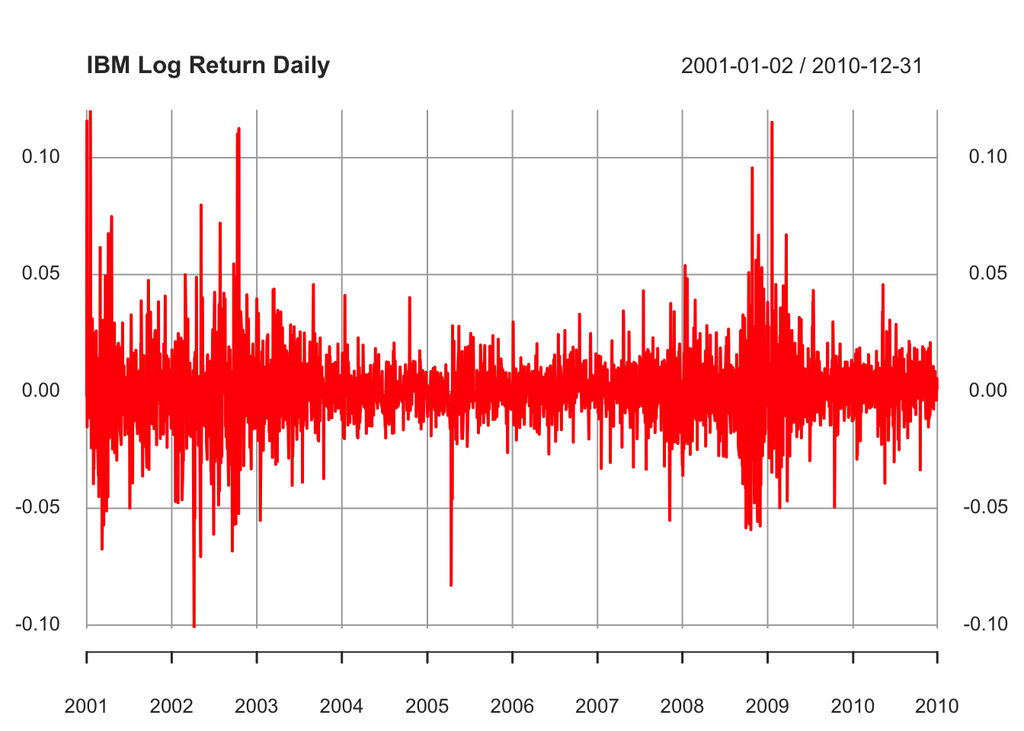

```r
ibmrtn <- xts(d[["return"]], d[["date"]])
plot(ibmrtn,
  main="IBM Log Return Daily",
  major.ticks="years", minor.ticks=NULL,
  grid.ticks.on="years",
  format.labels="%Y",
  col="red")
```

可直接使用`plot`进行绘制收益率曲线。

和`ts`对象一样，`xts`的时间索引也是隐式的，可以使用`index()`提取索引，使用`coredata()`提取观测序列：

```r
library(TSstudio)
library(xts)
data(Michigan_CS)
Mi_data<-coredata(Michigan_CS)
head(Mi_data)
```

```
##      [,1]
## [1,] 67.0
## [2,] 66.9
## [3,] 56.5
## [4,] 52.7
## [5,] 51.7
## [6,] 58.7
```

```r
#Mi_index<-index()
#head(Mi_index)
```

使用`as.xts()`可将非xts的时间序列数据转换为xts类型的时间序列数据。而使用`xts`可以将一般的向量转换为时间序列数据，

```r
data = runif(5)
time<-as.Date(paste("2023-01-0",1:5,sep=""))
exam<-xts(x=data,order.by=time)
ts_info(exam)
```

```
##  The exam series is a xts object with 1 variable and 5 observations
##  Frequency: daily
##  Start time: 2023-01-01
##  End time: 2023-01-05
```

### `ts`类型数据

`ts`是R中对时间序列数据的支持。是在stats包内的，也是R中较为常用的包用于对时间序列数据进行操作的数据类型。

```r
yd <- ts(
  c(4, 8, 7, 7, 3, 1, 8, 9, 8, 6, 3, 5,
    5, 8, 2, 5, 9, 2, 5, 2, 3, 2, 2, 4),
  frequency=1, start=2001); yd
```

```
## Time Series:
## Start = 2001
## End = 2024
## Frequency = 1
##  [1] 4 8 7 7 3 1 8 9 8 6 3 5 5 8 2 5 9 2 5 2 3 2 2 4
```

默认的时间频率为以年为单位，同样也可以调整为12，即为月为单位。

```r
ym <- ts(
  c(9, 6, 3, 5, 4, 8, 2, 5, 8, 4, 6, 3,
    2, 2, 6, 4, 1, 4, 2, 1, 8, 9, 4, 6),
  frequency=12, start=c(2001,1)); ym
```

```
##      Jan Feb Mar Apr May Jun Jul Aug Sep Oct Nov Dec
## 2001   9   6   3   5   4   8   2   5   8   4   6   3
## 2002   2   2   6   4   1   4   2   1   8   9   4   6
```

```r
library(tidyverse)
library(lubridate)
d <- read_table(
  "/Users/a182501/project_set/fts/ftsdata/d-ibm-0110.txt", col_types=cols(
    .default=col_double(),
    date=col_date(format="%Y%m%d")))
d
```

```
## # A tibble: 2,515 × 2
##    date         return
##    <date>        <dbl>
##  1 2001-01-02 -0.00221
##  2 2001-01-03  0.116
##  3 2001-01-04 -0.0152
##  4 2001-01-05  0.00872
##  5 2001-01-08 -0.00465
##  6 2001-01-09 -0.0107
##  7 2001-01-10  0.00945
##  8 2001-01-11  0.00268
##  9 2001-01-12  0.00133
## 10 2001-01-16 -0.0113
## # ℹ 2,505 more rows
```

```r
x <- scan("/Users/a182501/project_set/fts/bp500-2691.txt",skip = 1)
ts(x, start=c(2001, 1), frequency=12)
```

```
##          Jan     Feb     Mar     Apr     May     Jun     Jul     Aug     Sep
## 2001  0.0225 -0.0440 -0.0591  0.0227  0.0077  0.0432  0.0455  0.0171  0.0229
## 2002 -0.0208  0.0477  0.0065  0.0172  0.0522 -0.0094  0.0650  0.0445  0.0432
## 2003 -0.0051 -0.0176  0.1083  0.0324  0.0127 -0.0405  0.0125  0.0741  0.0240
## 2004  0.0571 -0.0058 -0.0023  0.0161 -0.0428  0.1124  0.0456  0.0980 -0.0489
## 2005  0.0625  0.0215  0.0799 -0.0095 -0.0165 -0.1646  0.0367  0.0075 -0.1301
## 2006  0.0489  0.1144 -0.0692 -0.0959 -0.1372  0.1390 -0.0742  0.0095 -0.2994
## 2007 -0.0283  0.0507 -0.1182 -0.2025 -0.2333 -0.0089  0.3770  0.3754 -0.0369
## 2008  0.0073 -0.1844  0.0336  0.4222  0.1587  0.1317 -0.0880  0.1146 -0.1136
## 2009  0.1059 -0.0367 -0.0009 -0.0270 -0.0813  0.0208 -0.1152  0.0541 -0.0055
## 2010 -0.0421 -0.0396 -0.0309  0.0956  0.0323  0.0678  0.0831  0.0217  0.0239
## 2011  0.0655  0.0168  0.0254 -0.0771  0.0458  0.0306  0.0681  0.0088  0.0013
## 2012  0.0378  0.0146 -0.0094 -0.0831 -0.0103 -0.0529  0.1026 -0.0554 -0.1421
## 2013  0.0133  0.0608 -0.2504  0.1412 -0.0443  0.2470  0.0727 -0.0274  0.0149
## 2014 -0.0689  0.0325 -0.1354 -0.0055  0.0623 -0.0638  0.1087 -0.0714  0.1646
```

[output cut: 119 more lines]

```r
d <- read.table(
  "/Users/a182501/project_set/fts/ftsdata/m-unrate.txt", header=TRUE,
  colClasses=rep("numeric", 4))
unrate <- ts(d[["rate"]], start=c(1948,1), frequency=12)
class(unrate)
```

```
## [1] "ts"
```

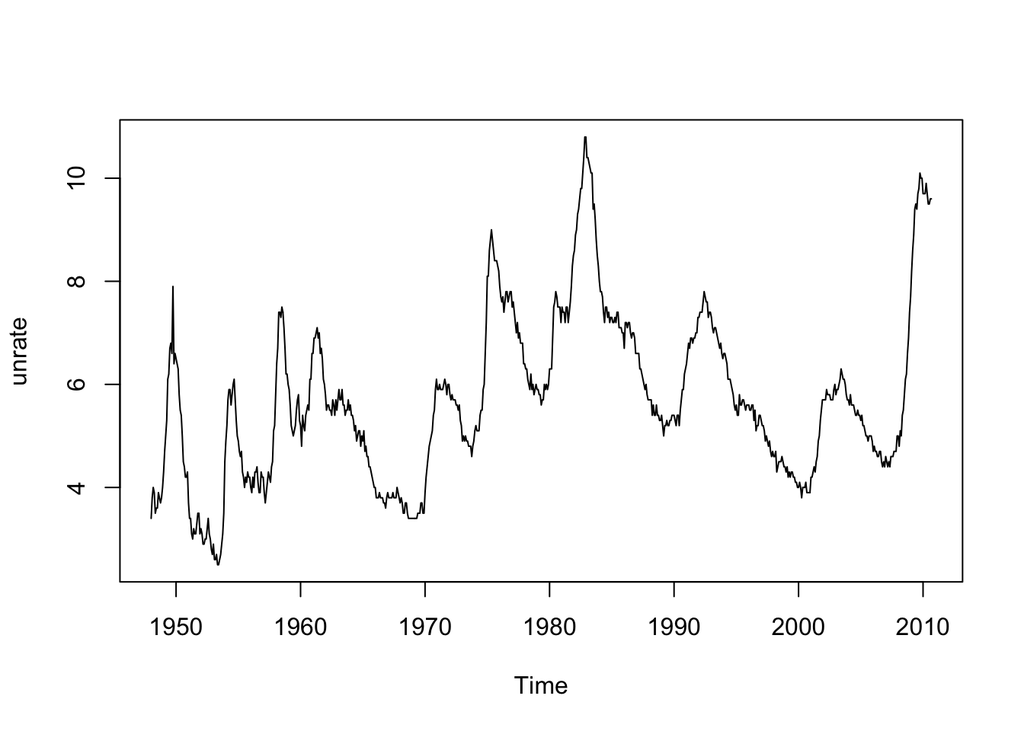

```r
plot(unrate)
```

### `tsibble`类型

tsibble包提供了tsibble数据类型，是从tidyverse宇宙中扩展出来的一种时间序列处理方法。

一个简单的创建方法：

```r
library(tsibble)
t1<-tsibble(date=as.Date("2023-03-01")+1:5,value=rnorm(5))
t1
```

```
## # A tsibble: 5 x 2 [1D]
##   date        value
##   <date>      <dbl>
## 1 2023-03-02  2.40
## 2 2023-03-03  0.764
## 3 2023-03-04 -0.799
## 4 2023-03-05 -1.15
## 5 2023-03-06 -0.289
```

```r
library(readr)
d <- read_table2(
  "/Users/a182501/project_set/fts/ftsdata/m-ibmsp-2611.txt",
  col_types=cols(.default=col_double(),
                 date=col_date(format="%Y%m%d")))
tsb <- as_tsibble(d, index="date")
class(tsb)
```

```
## [1] "tbl_ts"     "tbl_df"     "tbl"        "data.frame"
```

```r
head(tsb)
```

```
## # A tsibble: 6 x 3 [1D]
##   date           ibm       sp
##   <date>       <dbl>    <dbl>
## 1 1926-01-30 -0.0104  0.0225
## 2 1926-02-27 -0.0245 -0.0440
## 3 1926-03-31 -0.116  -0.0591
## 4 1926-04-30  0.0898  0.0227
## 5 1926-05-28  0.0369  0.00768
## 6 1926-06-30  0.0685  0.0432
```

其中tsibble的一大特点是引入tibble数据框到时序数据中。

```r
# install.packages("nycflights13")
library(nycflights13)
data(weather)
weather_tsbl<-weather%>%
             select(origin, time_hour, temp, humid, precip)%>%
             as_tsibble(index=time_hour,key=origin)
head(weather_tsbl)
```

[output not shown]

同时我们可以看到这里有索引(index)、键(key)，每个观测值都是与键进行唯一识别。若间隔是有规律的，那么每一个观测单元共用一个区间进行测量。

#### 处理`tsibble`对象

`tsibble`有一个关键函数`index_by()`对应于`dplyr`中的`group_by()`，按照索引进行划分组别。

```r
precipavg_week<-weather_tsbl %>%
  group_by_key() %>%
  index_by(year_week = ~ yearweek(.)) %>%
  summarise(precip_avg = mean(precip,na.rm=T))
```

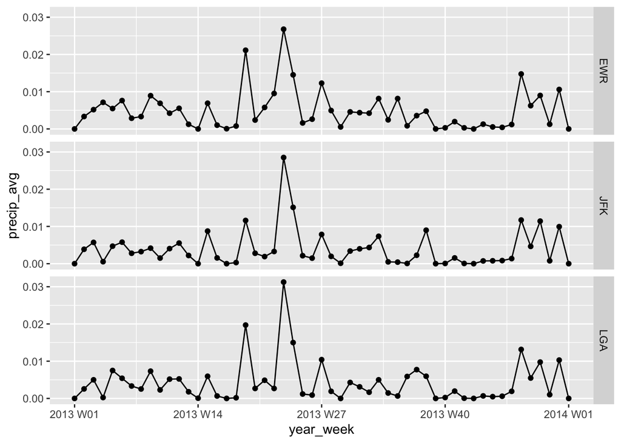

```r
precipavg_week%>%
ggplot(aes(x=year_week,y=precip_avg))+
geom_point()+
geom_line()+
facet_grid(origin ~ .)
```

## 金融数据获取

### `quantmod`

quantmod包的目的是为量化投资者提供方便的原型开发测试工具， 而不是提供新的统计方法。 quantmod包提供了金融时间序列数据的一些方便功能， 比如从公开数据源载入数据， 作股票行情图、时间序列图。

`getSymbols`函数能够帮助我们从多个公开数据源下载金融数据（需要使用VPN）。

```r
pacman::p_load(quantmod)
MSFT <- getSymbols("MSFT", src="yahoo", auto.assign = FALSE)
head(MSFT)
```

```
##            MSFT.Open MSFT.High MSFT.Low MSFT.Close MSFT.Volume MSFT.Adjusted
## 2007-01-03     29.91     30.25    29.40      29.86    76935100      21.57305
## 2007-01-04     29.70     29.97    29.44      29.81    45774500      21.53692
## 2007-01-05     29.63     29.75    29.45      29.64    44607200      21.41410
## 2007-01-08     29.65     30.10    29.53      29.93    50220200      21.62362
## 2007-01-09     30.00     30.18    29.73      29.96    44636600      21.64528
## 2007-01-10     29.80     29.89    29.43      29.66    55017400      21.42855
```

获取失业率数据：

```r
UNRATE <- getSymbols("UNRATE", src="FRED", auto.assign=FALSE)
head(UNRATE)
```

```
##            UNRATE
## 1948-01-01    3.4
## 1948-02-01    3.8
## 1948-03-01    4.0
## 1948-04-01    3.9
## 1948-05-01    3.5
## 1948-06-01    3.6
```

获取国债数据：

```r
MSFT <- getSymbols("MSFT", src="yahoo", auto.assign = FALSE)
TNX <- getSymbols("^TNX", auto.assign = FALSE) # CBOE 10年国债日数据
```

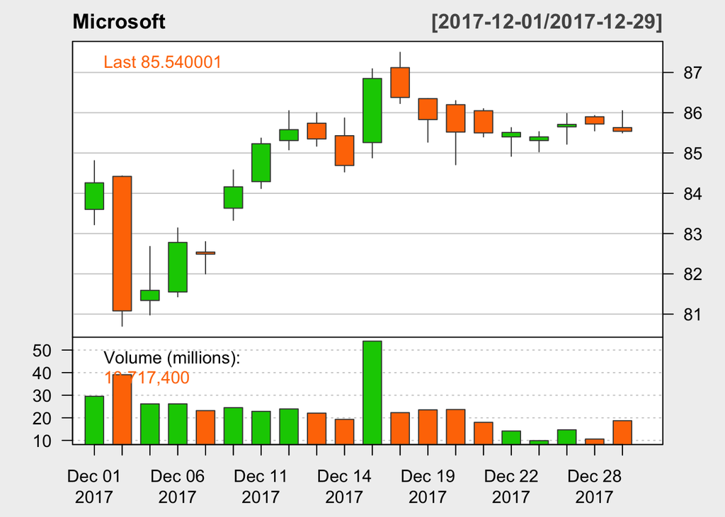

```r
chartSeries(MSFT, theme="white", name="Microsoft",
            subset="2017-12-01/2017-12-31")
```

```r
quantmod::getSymbols.FRED(
  Symbols = "IPB50001SQ",
  env = .GlobalEnv
)
```

```
## [1] "IPB50001SQ"
```

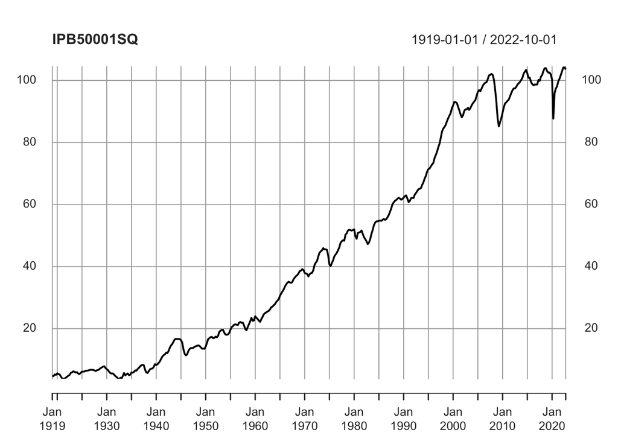

```r
plot(IPB50001SQ)
```

另一个方法是在函数`getSymbols`中的src`参数中设置为`FRED`。

```r
getSymbols('CPIAUCNS',src='FRED')
```

```
## [1] "CPIAUCNS"
```

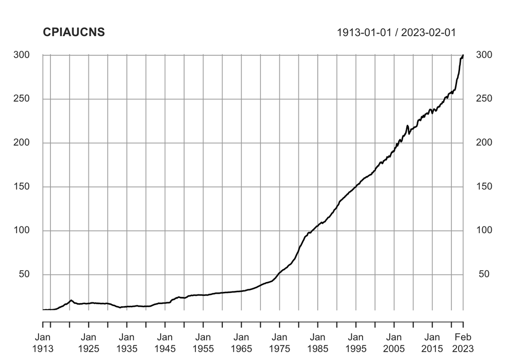

```r
plot(CPIAUCNS)
```

### tseries

还有一个包是`tseries`能够帮助我们获取最新的金融数据（也需要VPN）。

```r
pacman::p_load(tseries)
x <- get.hist.quote(instrument = "^gspc", start = "1998-01-01",
                      quote = "Close")
```

```
## time series starts 1998-01-02
## time series ends   2023-03-23
```

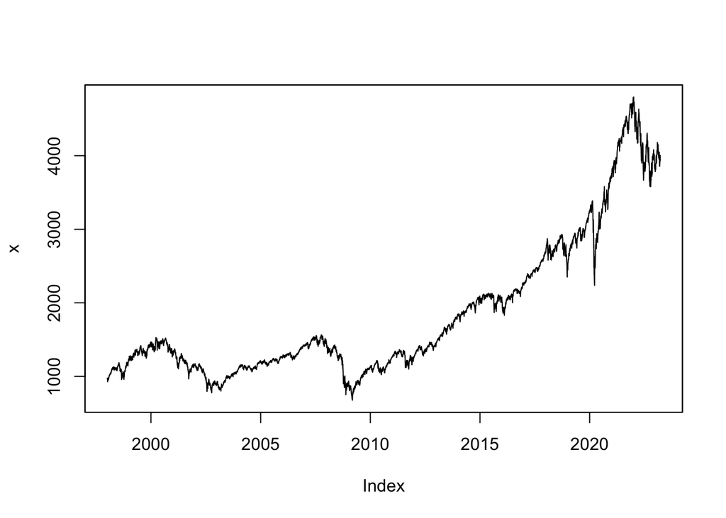

```r
plot(x)
```

```r
x <- get.hist.quote(instrument = "ibm", quote = c("Cl", "Vol"))
```

[output not shown]

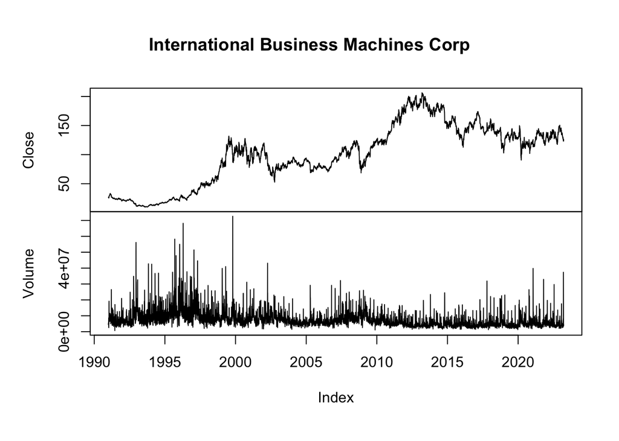

```r
plot(x, main = "International Business Machines Corp")
```